# Data analysis of the U.S. National Oceanic and Atmospheric Administration’s (NOAA) storm database

Morozov Gleb

Sunday, April 26, 2015

# Synopsis

Storms and other severe weather events can cause both public health and economic problems for communities and municipalities. Many severe events can result in fatalities, injuries, and property damage, and preventing such outcomes to the extent possible is a key concern.

The report explores U.S. National Oceanic and Atmospheric Administration’s (NOAA) dataset. This dataset contains gathered statistical data on weather events for period 1950-2011 years. It also includes information on healthy and economycal damage.

The report target is to represent the top 10 most dangerous weather events from health and economic points of view. Also aggregated impact data by event type is available. Economy damage is calculated as sum of crop and property damages.

# Data Processing

Loading packages

```r
library(ggplot2)
library(dplyr)
library(magrittr)
```

Loading the dataset. Link availability was checked on April 26 2015

```r
fileUrl <- "https://d396qusza40orc.cloudfront.net/repdata%2Fdata%2FStormData.csv.bz2"
download.file(fileUrl, "stormdata.csv.bz2", mode = "wb", method="curl")
data <- read.csv("stormdata.csv.bz2", stringsAsFactors = F)
```

Look at the raw data

```r
str(data)
```

```
## 'data.frame':    902297 obs. of  37 variables:
##  $ STATE__   : num  1 1 1 1 1 1 1 1 1 1 ...
##  $ BGN_DATE  : Factor w/ 16335 levels "1/1/1966 0:00:00",..: 6523 6523 4242 11116 2224 2224 2260 383 3980 3980 ...
##  $ BGN_TIME  : Factor w/ 3608 levels "00:00:00 AM",..: 272 287 2705 1683 2584 3186 242 1683 3186 3186 ...
##  $ TIME_ZONE : Factor w/ 22 levels "ADT","AKS","AST",..: 7 7 7 7 7 7 7 7 7 7 ...
##  $ COUNTY    : num  97 3 57 89 43 77 9 123 125 57 ...
##  $ COUNTYNAME: Factor w/ 29601 levels "","5NM E OF MACKINAC BRIDGE TO PRESQUE ISLE LT MI",..: 13513 1873 4598 10592 4372 10094 1973 23873 24418 4598 ...
##  $ STATE     : Factor w/ 72 levels "AK","AL","AM",..: 2 2 2 2 2 2 2 2 2 2 ...
##  $ EVTYPE    : Factor w/ 985 levels "   HIGH SURF ADVISORY",..: 834 834 834 834 834 834 834 834 834 834 ...
##  $ BGN_RANGE : num  0 0 0 0 0 0 0 0 0 0 ...
##  $ BGN_AZI   : Factor w/ 35 levels "","  N"," NW",..: 1 1 1 1 1 1 1 1 1 1 ...
##  $ BGN_LOCATI: Factor w/ 54429 levels "","- 1 N Albion",..: 1 1 1 1 1 1 1 1 1 1 ...
##  $ END_DATE  : Factor w/ 6663 levels "","1/1/1993 0:00:00",..: 1 1 1 1 1 1 1 1 1 1 ...
##  $ END_TIME  : Factor w/ 3647 levels ""," 0900CST",..: 1 1 1 1 1 1 1 1 1 1 ...
##  $ COUNTY_END: num  0 0 0 0 0 0 0 0 0 0 ...
```

[output cut: 23 more lines]

Select only related columns and cast analised strings to equal case

```r
names(data) <- tolower(names(data))
data %<>% select(evtype, fatalities:cropdmgexp) %>%
        mutate(cropdmgexp = tolower(cropdmgexp)) %>%
        mutate(propdmgexp = tolower(propdmgexp)) %>%
        mutate(evtype = tolower(evtype))
str(data)
```

```
## 'data.frame':    902297 obs. of  7 variables:
##  $ evtype    : chr  "tornado" "tornado" "tornado" "tornado" ...
##  $ fatalities: num  0 0 0 0 0 0 0 0 1 0 ...
##  $ injuries  : num  15 0 2 2 2 6 1 0 14 0 ...
##  $ propdmg   : num  25 2.5 25 2.5 2.5 2.5 2.5 2.5 25 25 ...
##  $ propdmgexp: chr  "k" "k" "k" "k" ...
##  $ cropdmg   : num  0 0 0 0 0 0 0 0 0 0 ...
##  $ cropdmgexp: chr  "" "" "" "" ...
```

Look at the number of occurrences of the event types

```r
data %>% select(evtype) %>%
        group_by(evtype) %>%
        summarise(freq = n()) %>%
        arrange(desc(freq)) %T>%
        print(n = 15) %>%
        with(cat("Fraction first ten event types:", round(sum(freq[1:10])/sum(freq), 2)*100, "%"))
```

```
## Source: local data frame [898 x 2]
##
##                evtype   freq
## 1                hail 288661
## 2           tstm wind 219942
## 3   thunderstorm wind  82564
## 4             tornado  60652
## 5         flash flood  54277
## 6               flood  25327
## 7  thunderstorm winds  20843
## 8           high wind  20214
## 9           lightning  15754
## 10         heavy snow  15708
## 11         heavy rain  11742
## 12       winter storm  11433
## 13     winter weather   7045
## 14       funnel cloud   6844
## 15   marine tstm wind   6175
## ..                ...    ...
## Fraction first ten event types: 89 %
```

Combine together *thunderstorm winds*, *thunderstorm wind*, *tstm wind*

```r
data$evtype %<>% gsub("thunderstorm winds", "thunderstorm wind", .) %>%
        gsub("tstm wind", "thunderstorm wind", .)
data %>% select(evtype) %>%
        group_by(evtype) %>%
        summarise(freq = n()) %>%
        arrange(desc(freq)) %T>%
        print(n = 10) %>%
        with(cat("Fraction first ten event type:", round(sum(freq[1:10])/sum(freq), 2)*100, "%"))
```

```
## Source: local data frame [884 x 2]
##
##                      evtype   freq
## 1         thunderstorm wind 323349
## 2                      hail 288661
## 3                   tornado  60652
## 4               flash flood  54277
## 5                     flood  25327
## 6                 high wind  20214
## 7                 lightning  15754
## 8                heavy snow  15708
## 9  marine thunderstorm wind  11987
## 10               heavy rain  11742
## ..                      ...    ...
## Fraction first ten event type: 92 %
```

```r
data %>% select(propdmgexp) %>%
        group_by(propdmgexp) %>%
        summarise(freq = n()) %>%
        arrange(desc(freq))
```

```
## Source: local data frame [17 x 2]
##
##    propdmgexp   freq
## 1             465934
## 2           k 424665
## 3           m  11337
## 4           0    216
## 5           b     40
## 6           5     28
## 7           1     25
## 8           2     13
## 9           ?      8
## 10          h      7
## 11          +      5
## 12          7      5
## 13          3      4
## 14          4      4
## 15          6      4
## 16          -      1
## 17          8      1
```

```r
data$propdmgexp %<>% gsub("k", "3", .) %>%
        gsub("m", "6", .) %>%
        gsub("b", "9", .) %>%
        gsub("\\?", "1", .) %>%
        gsub("h", "2", .) %>%
        gsub("\\+", "1", .) %>%
        gsub("\\-", "1", .)
data$propdmgexp <- as.numeric(data$propdmgexp)
data$propdmgexp[is.na(data$propdmgexp)] <- 0
data %>% select(propdmgexp) %>%
        group_by(propdmgexp) %>%
        summarise(freq = n()) %>%
        arrange(desc(freq))
```

```
## Source: local data frame [10 x 2]
##
##    propdmgexp   freq
## 1           0 466150
## 2           3 424669
## 3           6  11341
## 4           9     40
## 5           1     39
## 6           5     28
## 7           2     20
## 8           7      5
## 9           4      4
## 10          8      1
```

Also in *cropdmgexp*

```r
data$cropdmgexp %<>% gsub("k", "3", .) %>%
        gsub("m", "6", .) %>%
        gsub("b", "9", .) %>%
        gsub("\\?", "1", .)
data$cropdmgexp <- as.numeric(data$cropdmgexp)
data$cropdmgexp[is.na(data$cropdmgexp)] <- 0
data %>% select(cropdmgexp) %>%
        group_by(cropdmgexp) %>%
        summarise(freq = n()) %>%
        arrange(desc(freq))
```

```
## Source: local data frame [6 x 2]
##
##   cropdmgexp   freq
## 1          0 618432
## 2          3 281853
## 3          6   1995
## 4          9      9
## 5          1      7
## 6          2      1
```

Add new columns that sums property and crop damage

```r
data %<>% mutate(dmg = (propdmg * 10^propdmgexp) + (cropdmg * 10^cropdmgexp))
```

Look at the first ten events sorted by economic damage

```r
data %>%group_by(evtype) %>%
        summarise(sumdmg = sum(dmg)) %>%
        arrange(desc(sumdmg))
```

```
## Source: local data frame [884 x 2]
##
##               evtype       sumdmg
## 1              flood 150319678257
## 2  hurricane/typhoon  71913712800
## 3            tornado  57362334487
## 4        storm surge  43323541000
## 5               hail  18761221986
## 6        flash flood  18243991079
## 7            drought  15018672000
## 8          hurricane  14610229010
## 9  thunderstorm wind  11072177014
## 10       river flood  10148404500
## ..               ...          ...
```

Combine together *hurricane* and *hurricane/typhoon*, *river flood* and *flood*

```r
data$evtype %<>% gsub("hurricane", "hurricane/typhoon", .) %>%
        gsub("river flood", "flood", .) %>%
        gsub("/typhoon", "", .)
```

# Results

## Question 1: Across the United States, which types of events are most harmful with respect to population health?

The results for fatal events and injuries are presented separately since I consider that fatal events are more harmful with respect to the population healt than injuries.

### Total Fatalities by Weather Events in the U.S.

The top 10 event types with the highest number of fatalities are presented in the following barplot:

```
## Source: local data frame [881 x 2]
##
##               evtype sumfat
## 1            tornado   5633
## 2     excessive heat   1903
## 3        flash flood    978
## 4               heat    937
## 5          lightning    816
## 6  thunderstorm wind    701
## 7              flood    472
## 8        rip current    368
## 9          high wind    248
## 10         avalanche    224
## ..               ...    ...
```

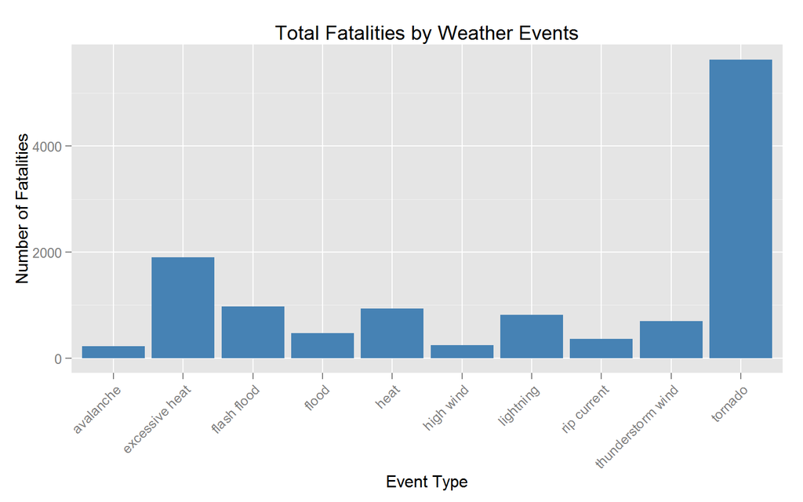

```r
data %>%group_by(evtype) %>%
        summarise(sumfat = sum(fatalities)) %>%
        arrange(desc(sumfat)) %T>%
        print(n = 10) %>%
        slice(1:10) %>%
        qplot(data = ., y = sumfat, x = evtype, geom = "bar", fill = I("steelblue"), stat = "identity") +
        labs(x="Event Type", y="Number of Fatalities", title="Total Fatalities by Weather Events") +
        theme(axis.text.x = element_text(angle = 45, hjust = 1))
```

### Total Injuries by Weather Events in the U.S.

The top 10 event types with the highest number of injuries are presented in the following barplot:

```
## Source: local data frame [881 x 2]
##
##               evtype suminj
## 1            tornado  91346
## 2  thunderstorm wind   9353
## 3              flood   6791
## 4     excessive heat   6525
## 5          lightning   5230
## 6               heat   2100
## 7          ice storm   1975
## 8        flash flood   1777
## 9               hail   1361
## 10         hurricane   1321
## ..               ...    ...
```

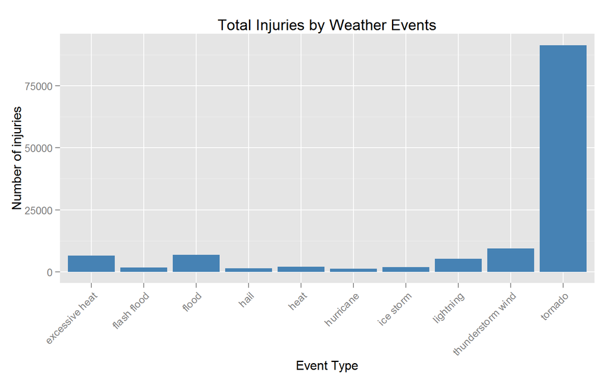

```r
data %>%group_by(evtype) %>%
        summarise(suminj = sum(injuries)) %>%
        arrange(desc(suminj)) %T>%
        print(n = 10) %>%
        slice(1:10) %>%
        qplot(data = ., y = suminj, x = evtype, geom = "bar", fill = I("steelblue"), stat = "identity") +
        labs(x="Event Type", y="Number of injuries", title="Total Injuries by Weather Events") +
        theme(axis.text.x = element_text(angle = 45, hjust = 1))
```

## Question 2: Across the United States, which types of events have the greatest economic consequences?

The top 10 event types with the highest amount of economic damages are presented in the following barplot:

```
## Source: local data frame [881 x 2]
##
##               evtype       sumdmg
## 1              flood 160468082757
## 2          hurricane  86523941810
## 3            tornado  57362334487
## 4        storm surge  43323541000
## 5               hail  18761221986
## 6        flash flood  18243991079
## 7            drought  15018672000
## 8  thunderstorm wind  11072177014
## 9          ice storm   8967041360
## 10    tropical storm   8382236550
## ..               ...          ...
```

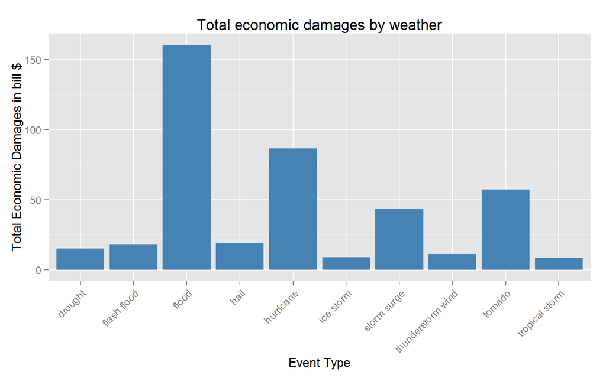

```r
data %>%group_by(evtype) %>%
        summarise(sumdmg = sum(dmg)) %>%
        arrange(desc(sumdmg)) %T>%
        print(n = 10) %>%
        slice(1:10) %>%
        qplot(data = ., y = sumdmg/(10^9), x = evtype, geom = "bar", fill=I("steelblue"), stat="identity") +
        labs(x="Event Type", y="Total Economic Damages in bill $", title="Total economic damages by weather") +
        theme(axis.text.x = element_text(angle = 45, hjust = 1))
```

# Conclusion

As shown from the report, the most dangerous weather event is tornado and the flood consequences are the most expensive.